# Homework 5 - BSTA 522

Matthew Hoctor

2/7/2022

# Part 2

Read paper 5a and report (up to 5 bullet points). It is a long paper. You may just read the main paper and skip the comments and rejoinder. But, you may be interested in reading them when you have more time, like during the spring break.

## Breiman Summary

- Breiman’s main thesis is that statisticians tend to think of analysis of data in two different ways: response variables can be a function of predictors, and models can be made to get closer to knowledge of how the natural world computes the response; alternatively algorithms generate outputs from inputs. Furthermore Breiman argues that the former way of thinking has resulted in decreased applicability of the field of statistics to other ventures.
- Breiman outlines current issues in the data modeling approach; these include poor approximation of the statistical model for the natural model, lack of use of goodness-of-fit tests, the consistency of datasets with multitudes of data models, and poor predictive accuracy due to lack of validation approaches.
- Breiman presents algorithmic models as an alternative. He states that primary examples of this approach include nural networks and decision trees.
- Several examples illustrating the potential benefits of these methods are given; examples include high dimensional data such as survival data, clustered medical data, genetic data, and random forests.

# Part 3

Chap 6: #2, #11; Always set a seed number for reproducibility.

## 6.2

### a

The lasso, relative to least squares, is:

Less flexible and hence will give improved prediction accuracy when its increase in bias is less than its decrease in variance. Lasso technique is a shrinkage method, and therefore it has the effect of reducing variance, at the expense of increasing compared to least squares. The lasso technique is less flexible because the sum of the absolute values of the parameters (except for the intercept) is constrained.

### b

Ridge regression relative to least squares, is:

Less flexible and hence will give improved prediction accuracy when its increase in bias is less than its decrease in variance. Similar to the lasso, ridge regression is a shrinkage method, and therefore it has the effect of reducing variance at the expense of increasing bias, when compared to least squares. Ridge regression is less flexible than least squares because the sum of the squares of the parameters (except for the intercept) is constrained.

### c

Non-linear methods relative to least squares, is:

More flexible and hence will give improved prediction accuracy when its increase in variance is less than its decrease in bias. Non-linear methods increase the number of parameters used to describe the relation of the variable to the response variable, and therefore are more flexible. This can decrease bias at the expense of an increase in variance.

## 6.11

We will now try to predict per capita crime rate in the Boston data set.

### Setup

Dataset specification

```r
boston <- Boston
```

Adding the predict() function for objects output from regsubsets() from the text:

```r
predict.regsubsets=function(object,newdata,id,...){
  form=as.formula(object$call[[2]])
  mat=model.matrix(form,newdata)
  coefi=coef(object,id=id)
  xvars=names(coefi)
  mat[,xvars]%*%coefi   # NB %*% is matrix cross-product
  }
```

### a

Try out some of the regression methods explored in this chapter, such as best subset selection, the lasso, ridge regression, and PCR. Present and discuss results for the approaches that you consider.

Note: in 11(a), try all models listed, not some, and elastic net.

#### Best Subset Selection

Exhaustive search

```r
regfit.ex <- regsubsets(crim ~ .,
                            data = boston,
                            method = "exhaustive",
                            nvmax = 13  #specifies max model size
                            )
regfit.ex.sum <- summary(regfit.ex)
regfit.ex.sum
```

```
## Subset selection object
## Call: regsubsets.formula(crim ~ ., data = boston, method = "exhaustive",
##     nvmax = 13)
## 13 Variables  (and intercept)
##         Forced in Forced out
## zn          FALSE      FALSE
## indus       FALSE      FALSE
## chas        FALSE      FALSE
## nox         FALSE      FALSE
## rm          FALSE      FALSE
## age         FALSE      FALSE
## dis         FALSE      FALSE
## rad         FALSE      FALSE
## tax         FALSE      FALSE
## ptratio     FALSE      FALSE
## black       FALSE      FALSE
## lstat       FALSE      FALSE
## medv        FALSE      FALSE
## 1 subsets of each size up to 13
## Selection Algorithm: exhaustive
##           zn  indus chas nox rm  age dis rad tax ptratio black lstat medv
## 1  ( 1 )  " " " "   " "  " " " " " " " " "*" " " " "     " "   " "   " "
## 2  ( 1 )  " " " "   " "  " " " " " " " " "*" " " " "     " "   "*"   " "
## 3  ( 1 )  " " " "   " "  " " " " " " " " "*" " " " "     "*"   "*"   " "
## 4  ( 1 )  "*" " "   " "  " " " " " " "*" "*" " " " "     " "   " "   "*"
## 5  ( 1 )  "*" " "   " "  " " " " " " "*" "*" " " " "     "*"   " "   "*"
## 6  ( 1 )  "*" " "   " "  "*" " " " " "*" "*" " " " "     "*"   " "   "*"
## 7  ( 1 )  "*" " "   " "  "*" " " " " "*" "*" " " "*"     "*"   " "   "*"
## 8  ( 1 )  "*" " "   " "  "*" " " " " "*" "*" " " "*"     "*"   "*"   "*"
## 9  ( 1 )  "*" "*"   " "  "*" " " " " "*" "*" " " "*"     "*"   "*"   "*"
## 10  ( 1 ) "*" "*"   " "  "*" "*" " " "*" "*" " " "*"     "*"   "*"   "*"
## 11  ( 1 ) "*" "*"   " "  "*" "*" " " "*" "*" "*" "*"     "*"   "*"   "*"
## 12  ( 1 ) "*" "*"   "*"  "*" "*" " " "*" "*" "*" "*"     "*"   "*"   "*"
## 13  ( 1 ) "*" "*"   "*"  "*" "*" "*" "*" "*" "*" "*"     "*"   "*"   "*"
```

```r
tidy(regfit.ex)
```

```
## # A tibble: 13 x 18
##    `(Intercept)` zn    indus chas  nox   rm    age   dis   rad   tax   ptratio
##    <lgl>         <lgl> <lgl> <lgl> <lgl> <lgl> <lgl> <lgl> <lgl> <lgl> <lgl>
##  1 TRUE          FALSE FALSE FALSE FALSE FALSE FALSE FALSE TRUE  FALSE FALSE
##  2 TRUE          FALSE FALSE FALSE FALSE FALSE FALSE FALSE TRUE  FALSE FALSE
##  3 TRUE          FALSE FALSE FALSE FALSE FALSE FALSE FALSE TRUE  FALSE FALSE
##  4 TRUE          TRUE  FALSE FALSE FALSE FALSE FALSE TRUE  TRUE  FALSE FALSE
##  5 TRUE          TRUE  FALSE FALSE FALSE FALSE FALSE TRUE  TRUE  FALSE FALSE
##  6 TRUE          TRUE  FALSE FALSE TRUE  FALSE FALSE TRUE  TRUE  FALSE FALSE
##  7 TRUE          TRUE  FALSE FALSE TRUE  FALSE FALSE TRUE  TRUE  FALSE TRUE
##  8 TRUE          TRUE  FALSE FALSE TRUE  FALSE FALSE TRUE  TRUE  FALSE TRUE
##  9 TRUE          TRUE  TRUE  FALSE TRUE  FALSE FALSE TRUE  TRUE  FALSE TRUE
## 10 TRUE          TRUE  TRUE  FALSE TRUE  TRUE  FALSE TRUE  TRUE  FALSE TRUE
## 11 TRUE          TRUE  TRUE  FALSE TRUE  TRUE  FALSE TRUE  TRUE  TRUE  TRUE
## 12 TRUE          TRUE  TRUE  TRUE  TRUE  TRUE  FALSE TRUE  TRUE  TRUE  TRUE
## 13 TRUE          TRUE  TRUE  TRUE  TRUE  TRUE  TRUE  TRUE  TRUE  TRUE  TRUE
## # ... with 7 more variables: black <lgl>, lstat <lgl>, medv <lgl>,
## #   r.squared <dbl>, adj.r.squared <dbl>, BIC <dbl>, mallows_cp <dbl>
```

We can plot the regfits() output with with plot.regsubsets:

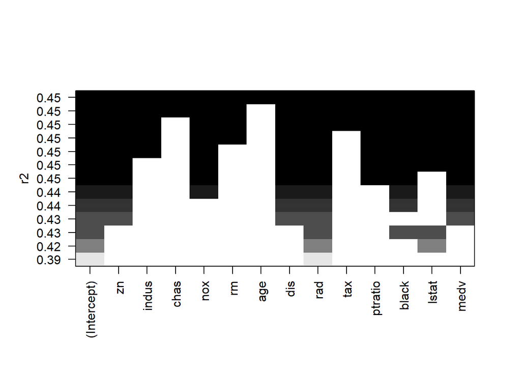

```r
plot(regfit.ex,
     scale = "r2")
```

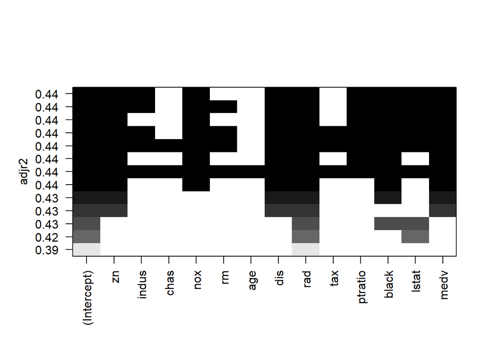

```r
plot(regfit.ex,
     scale = "adjr2")
```

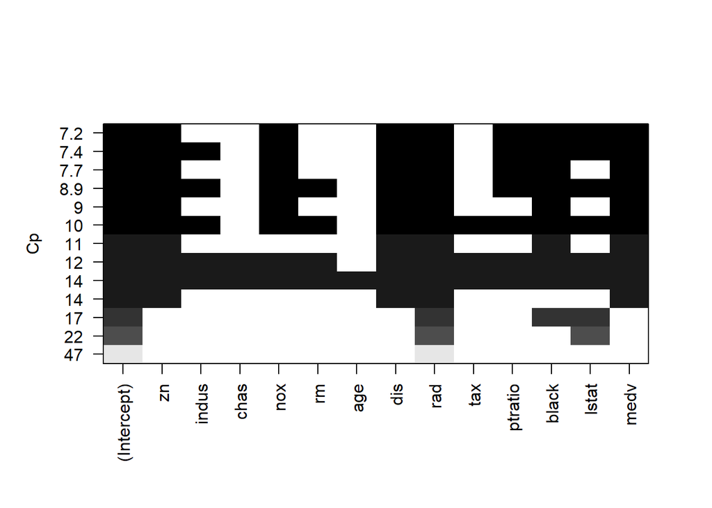

```r
plot(regfit.ex,
     scale = "Cp")
```

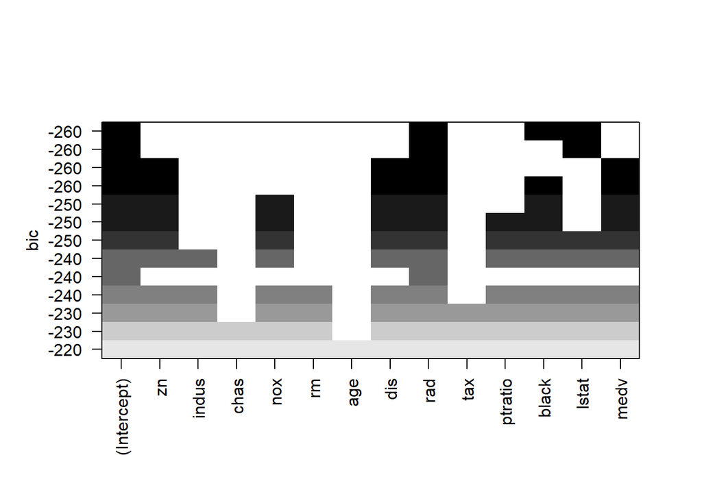

```r
plot(regfit.ex,
     scale = "bic")
```

```r
coef(regfit.ex, 2)
```

```
## (Intercept)         rad       lstat
##  -4.3814053   0.5228128   0.2372846
```

We can repeat the above analysis for the forward search method:

```r
regfit.fwd <- regsubsets(crim ~ .,
                            data = boston,
                            method = "forward",
                            nvmax = 13  #specifies max model size
                            )
regfit.fwd.sum <- summary(regfit.fwd)
regfit.fwd.sum
```

```
## Subset selection object
## Call: regsubsets.formula(crim ~ ., data = boston, method = "forward",
##     nvmax = 13)
## 13 Variables  (and intercept)
##         Forced in Forced out
## zn          FALSE      FALSE
## indus       FALSE      FALSE
## chas        FALSE      FALSE
## nox         FALSE      FALSE
## rm          FALSE      FALSE
## age         FALSE      FALSE
## dis         FALSE      FALSE
## rad         FALSE      FALSE
## tax         FALSE      FALSE
## ptratio     FALSE      FALSE
## black       FALSE      FALSE
## lstat       FALSE      FALSE
## medv        FALSE      FALSE
## 1 subsets of each size up to 13
## Selection Algorithm: forward
##           zn  indus chas nox rm  age dis rad tax ptratio black lstat medv
## 1  ( 1 )  " " " "   " "  " " " " " " " " "*" " " " "     " "   " "   " "
## 2  ( 1 )  " " " "   " "  " " " " " " " " "*" " " " "     " "   "*"   " "
## 3  ( 1 )  " " " "   " "  " " " " " " " " "*" " " " "     "*"   "*"   " "
## 4  ( 1 )  " " " "   " "  " " " " " " " " "*" " " " "     "*"   "*"   "*"
## 5  ( 1 )  "*" " "   " "  " " " " " " " " "*" " " " "     "*"   "*"   "*"
## 6  ( 1 )  "*" " "   " "  " " " " " " "*" "*" " " " "     "*"   "*"   "*"
## 7  ( 1 )  "*" " "   " "  "*" " " " " "*" "*" " " " "     "*"   "*"   "*"
## 8  ( 1 )  "*" " "   " "  "*" " " " " "*" "*" " " "*"     "*"   "*"   "*"
## 9  ( 1 )  "*" "*"   " "  "*" " " " " "*" "*" " " "*"     "*"   "*"   "*"
## 10  ( 1 ) "*" "*"   " "  "*" "*" " " "*" "*" " " "*"     "*"   "*"   "*"
## 11  ( 1 ) "*" "*"   " "  "*" "*" " " "*" "*" "*" "*"     "*"   "*"   "*"
## 12  ( 1 ) "*" "*"   "*"  "*" "*" " " "*" "*" "*" "*"     "*"   "*"   "*"
## 13  ( 1 ) "*" "*"   "*"  "*" "*" "*" "*" "*" "*" "*"     "*"   "*"   "*"
```

```r
tidy(regfit.fwd)
```

```
## # A tibble: 13 x 18
##    `(Intercept)` zn    indus chas  nox   rm    age   dis   rad   tax   ptratio
##    <lgl>         <lgl> <lgl> <lgl> <lgl> <lgl> <lgl> <lgl> <lgl> <lgl> <lgl>
##  1 TRUE          FALSE FALSE FALSE FALSE FALSE FALSE FALSE TRUE  FALSE FALSE
##  2 TRUE          FALSE FALSE FALSE FALSE FALSE FALSE FALSE TRUE  FALSE FALSE
##  3 TRUE          FALSE FALSE FALSE FALSE FALSE FALSE FALSE TRUE  FALSE FALSE
##  4 TRUE          FALSE FALSE FALSE FALSE FALSE FALSE FALSE TRUE  FALSE FALSE
##  5 TRUE          TRUE  FALSE FALSE FALSE FALSE FALSE FALSE TRUE  FALSE FALSE
##  6 TRUE          TRUE  FALSE FALSE FALSE FALSE FALSE TRUE  TRUE  FALSE FALSE
##  7 TRUE          TRUE  FALSE FALSE TRUE  FALSE FALSE TRUE  TRUE  FALSE FALSE
##  8 TRUE          TRUE  FALSE FALSE TRUE  FALSE FALSE TRUE  TRUE  FALSE TRUE
##  9 TRUE          TRUE  TRUE  FALSE TRUE  FALSE FALSE TRUE  TRUE  FALSE TRUE
## 10 TRUE          TRUE  TRUE  FALSE TRUE  TRUE  FALSE TRUE  TRUE  FALSE TRUE
## 11 TRUE          TRUE  TRUE  FALSE TRUE  TRUE  FALSE TRUE  TRUE  TRUE  TRUE
## 12 TRUE          TRUE  TRUE  TRUE  TRUE  TRUE  FALSE TRUE  TRUE  TRUE  TRUE
## 13 TRUE          TRUE  TRUE  TRUE  TRUE  TRUE  TRUE  TRUE  TRUE  TRUE  TRUE
## # ... with 7 more variables: black <lgl>, lstat <lgl>, medv <lgl>,
## #   r.squared <dbl>, adj.r.squared <dbl>, BIC <dbl>, mallows_cp <dbl>
```

We can plot the regfits() output with with plot.regsubsets:

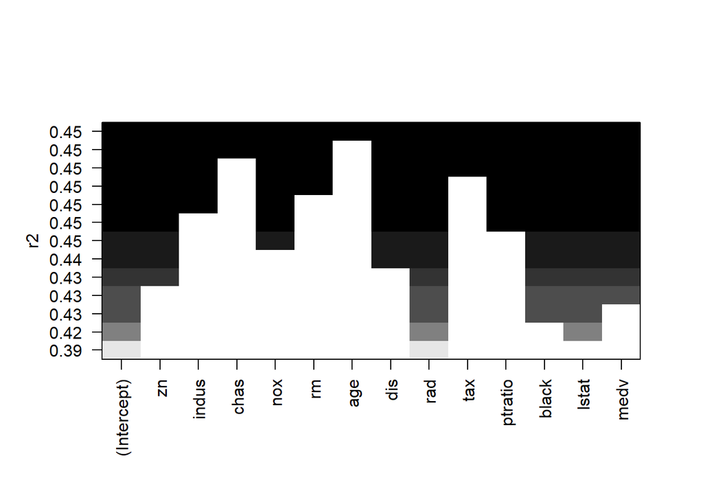

```r
plot(regfit.fwd,
     scale = "r2")
```

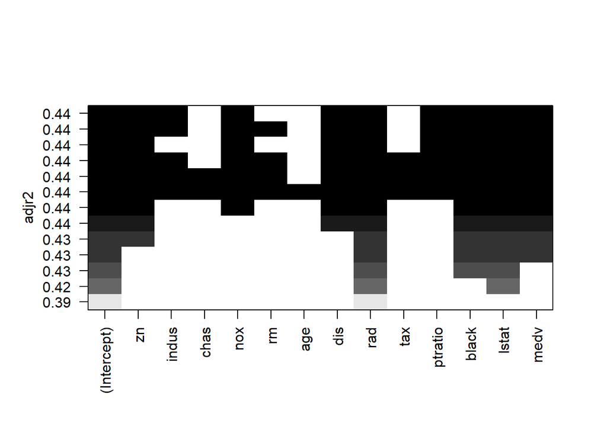

```r
plot(regfit.fwd,
     scale = "adjr2")
```

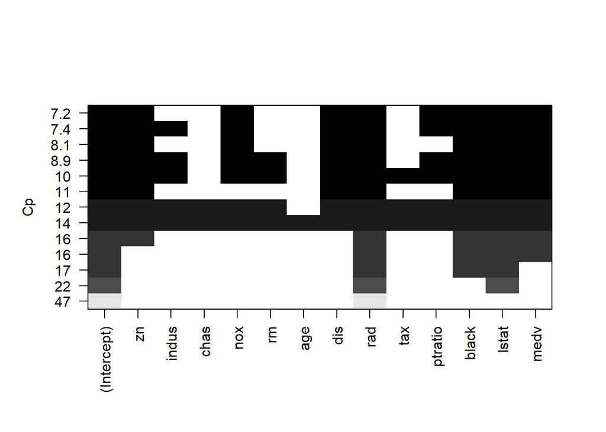

```r
plot(regfit.fwd,
     scale = "Cp")
```

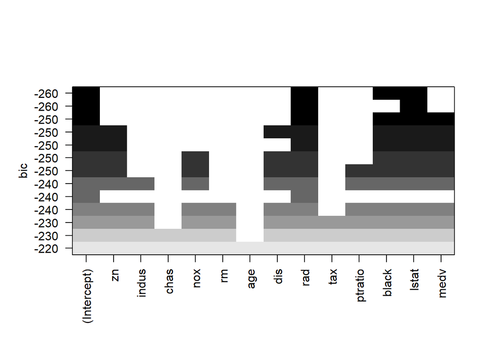

```r
plot(regfit.fwd,
     scale = "bic")
```

The output of the top line shows which variables are included in the optimal model, according to the criteria on the y-axis; $R^2$, as expected, selects all variables; adjusted $R^2$ selects all variables but Charles river proximity, home age, property tax rate, and number of rooms; Cp (AIC) selects all but industrial proportion, Charles river proximity, number of rooms, home age, and tax rate; and BIC selects only the intercept, highway accesability, socioeconomic status, and black race. We can view the coefficient estimates associated with the optimal BIC value with the coef() function:

```r
coef(regfit.fwd, 3)
```

```
##  (Intercept)          rad        black        lstat
## -0.372585457  0.488172386 -0.009471639  0.213595700
```

We can repeat the above analysis for the backward search method:

```r
regfit.bwd <- regsubsets(crim ~ .,
                            data = boston,
                            method = "backward",
                            nvmax = 13  #specifies max model size
                            )
regfit.bwd.sum <- summary(regfit.bwd)
regfit.bwd.sum
```

```
## Subset selection object
## Call: regsubsets.formula(crim ~ ., data = boston, method = "backward",
##     nvmax = 13)
## 13 Variables  (and intercept)
##         Forced in Forced out
## zn          FALSE      FALSE
## indus       FALSE      FALSE
## chas        FALSE      FALSE
## nox         FALSE      FALSE
## rm          FALSE      FALSE
## age         FALSE      FALSE
## dis         FALSE      FALSE
## rad         FALSE      FALSE
## tax         FALSE      FALSE
## ptratio     FALSE      FALSE
## black       FALSE      FALSE
## lstat       FALSE      FALSE
## medv        FALSE      FALSE
## 1 subsets of each size up to 13
## Selection Algorithm: backward
##           zn  indus chas nox rm  age dis rad tax ptratio black lstat medv
## 1  ( 1 )  " " " "   " "  " " " " " " " " "*" " " " "     " "   " "   " "
## 2  ( 1 )  " " " "   " "  " " " " " " " " "*" " " " "     " "   " "   "*"
## 3  ( 1 )  " " " "   " "  " " " " " " "*" "*" " " " "     " "   " "   "*"
## 4  ( 1 )  "*" " "   " "  " " " " " " "*" "*" " " " "     " "   " "   "*"
## 5  ( 1 )  "*" " "   " "  " " " " " " "*" "*" " " " "     "*"   " "   "*"
## 6  ( 1 )  "*" " "   " "  "*" " " " " "*" "*" " " " "     "*"   " "   "*"
## 7  ( 1 )  "*" " "   " "  "*" " " " " "*" "*" " " "*"     "*"   " "   "*"
## 8  ( 1 )  "*" " "   " "  "*" " " " " "*" "*" " " "*"     "*"   "*"   "*"
## 9  ( 1 )  "*" "*"   " "  "*" " " " " "*" "*" " " "*"     "*"   "*"   "*"
## 10  ( 1 ) "*" "*"   " "  "*" "*" " " "*" "*" " " "*"     "*"   "*"   "*"
## 11  ( 1 ) "*" "*"   " "  "*" "*" " " "*" "*" "*" "*"     "*"   "*"   "*"
## 12  ( 1 ) "*" "*"   "*"  "*" "*" " " "*" "*" "*" "*"     "*"   "*"   "*"
## 13  ( 1 ) "*" "*"   "*"  "*" "*" "*" "*" "*" "*" "*"     "*"   "*"   "*"
```

```r
tidy(regfit.bwd)
```

```
## # A tibble: 13 x 18
##    `(Intercept)` zn    indus chas  nox   rm    age   dis   rad   tax   ptratio
##    <lgl>         <lgl> <lgl> <lgl> <lgl> <lgl> <lgl> <lgl> <lgl> <lgl> <lgl>
##  1 TRUE          FALSE FALSE FALSE FALSE FALSE FALSE FALSE TRUE  FALSE FALSE
##  2 TRUE          FALSE FALSE FALSE FALSE FALSE FALSE FALSE TRUE  FALSE FALSE
##  3 TRUE          FALSE FALSE FALSE FALSE FALSE FALSE TRUE  TRUE  FALSE FALSE
##  4 TRUE          TRUE  FALSE FALSE FALSE FALSE FALSE TRUE  TRUE  FALSE FALSE
##  5 TRUE          TRUE  FALSE FALSE FALSE FALSE FALSE TRUE  TRUE  FALSE FALSE
##  6 TRUE          TRUE  FALSE FALSE TRUE  FALSE FALSE TRUE  TRUE  FALSE FALSE
##  7 TRUE          TRUE  FALSE FALSE TRUE  FALSE FALSE TRUE  TRUE  FALSE TRUE
##  8 TRUE          TRUE  FALSE FALSE TRUE  FALSE FALSE TRUE  TRUE  FALSE TRUE
##  9 TRUE          TRUE  TRUE  FALSE TRUE  FALSE FALSE TRUE  TRUE  FALSE TRUE
## 10 TRUE          TRUE  TRUE  FALSE TRUE  TRUE  FALSE TRUE  TRUE  FALSE TRUE
## 11 TRUE          TRUE  TRUE  FALSE TRUE  TRUE  FALSE TRUE  TRUE  TRUE  TRUE
## 12 TRUE          TRUE  TRUE  TRUE  TRUE  TRUE  FALSE TRUE  TRUE  TRUE  TRUE
## 13 TRUE          TRUE  TRUE  TRUE  TRUE  TRUE  TRUE  TRUE  TRUE  TRUE  TRUE
## # ... with 7 more variables: black <lgl>, lstat <lgl>, medv <lgl>,
## #   r.squared <dbl>, adj.r.squared <dbl>, BIC <dbl>, mallows_cp <dbl>
```

We can plot the regfits() output with with plot.regsubsets:

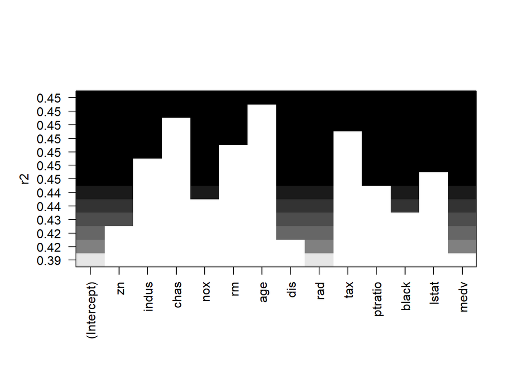

```r
plot(regfit.bwd,
     scale = "r2")
```

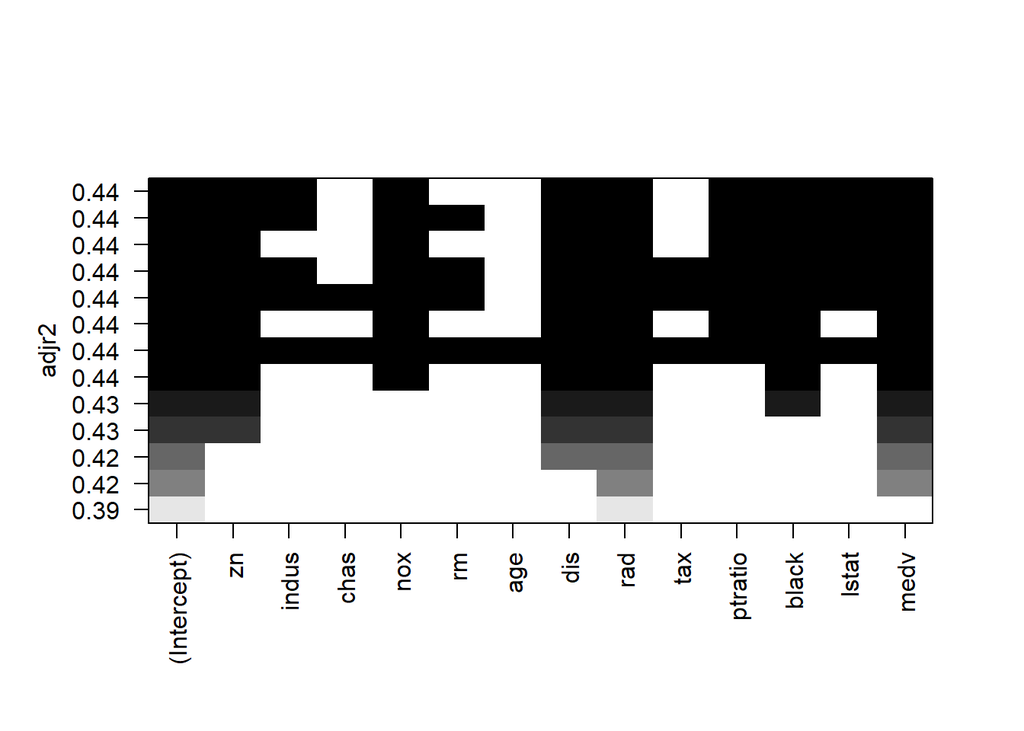

```r
plot(regfit.bwd,
     scale = "adjr2")
```

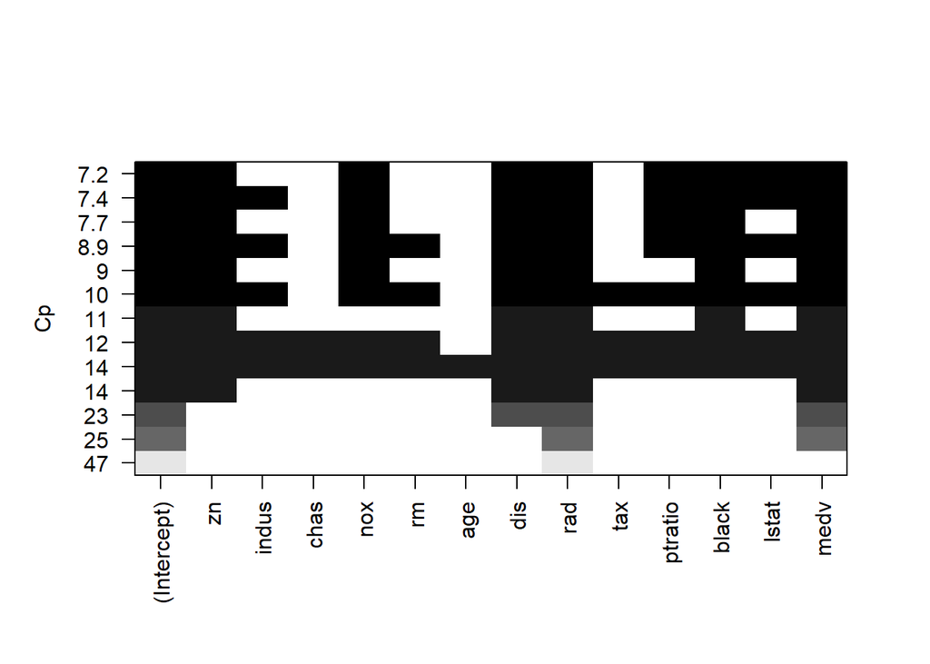

```r
plot(regfit.bwd,
     scale = "Cp")
```

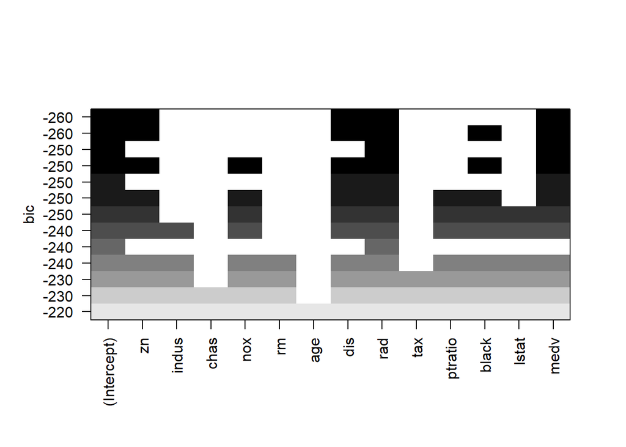

```r
plot(regfit.bwd,
     scale = "bic")
```

The output of the top line shows which variables are included in the optimal model, according to the criteria on the y-axis; $R^2$, as expected, selects all variables; adjusted $R^2$ selects all variables but Charles river proximity, home age, property tax rate, and number of rooms; Cp (AIC) selects all but industrial proportion, Charles river proximity, number of rooms, home age, and tax rate; and BIC selects only the intercept, industrial zoning, distance from employment, highway accesibility, and median home value. We can view the coefficient estimates associated with the optimal BIC value with the coef() function:

```r
coef(regfit.bwd, 4)
```

```
## (Intercept)          zn         dis         rad        medv
##  5.26547997  0.05486634 -0.72291374  0.50020971 -0.19121698
```

#### Lasso

This code specifies model matricies as x values, and crime rate vector as y values for the shrinkage methods:

```r
x <- model.matrix(crim ~ .,
                  data = boston)
y <- boston$crim
```

As in the example in the text, we will choose a range of $\lambda$ values from $10^{-2}$ to $10^{10}$, and fit models for this range of parameters:

```r
grid <- 10^seq(10, -2, length = 100)  #specifies 100 lambda values
```

The following code creates the lasso model and plots the coefficients as a function of log-$\lambda$:

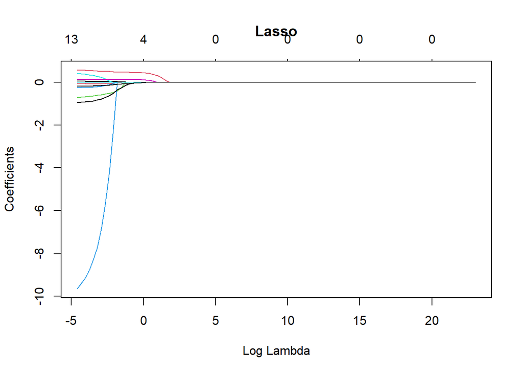

```r
lasso.model <- glmnet(x,
                      y,
                      alpha = 1,      #specifies lasso
                      lambda = grid)
plot(lasso.model,
     xvar = "lambda",
     main = "Lasso")
```

We will revisit the models created in part a for evaluation using the validation set approach. Note that the above code chunk did not take a significant amount of run time without the use of multi-core computing. Running the sample parallelization code from class caused my R session to abort.

#### Ridge Regression

The following code creates the ridge regression model and plots the coefficients as a function of log-$\lambda$:

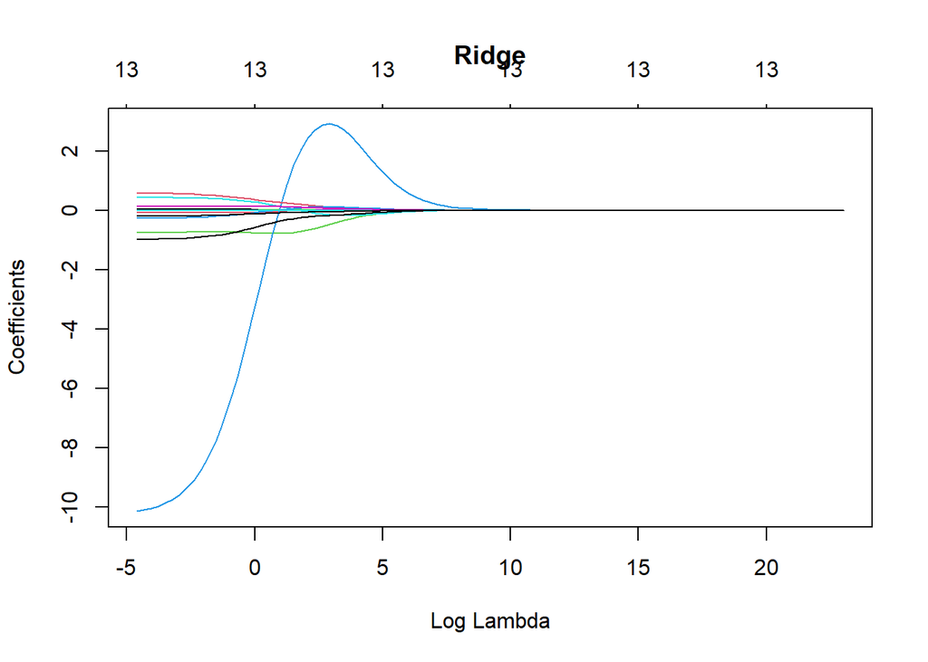

```r
ridge.model <- glmnet(x,
                      y,
                      alpha = 0,      #specifies ridge regression
                      lambda = grid)
plot(ridge.model,
     xvar = "lambda",
     main = "Ridge")
```

We will revisit the models created in part a for evaluation using the validation set approach. Note that the above code chunk did not take a significant amount of run time without the use of multi-core computing. Running the sample parallelization code from class caused my R session to abort.

#### Elastic Net

The following code creates the elastic net model and plots the coefficients as a function of log-$\lambda$:

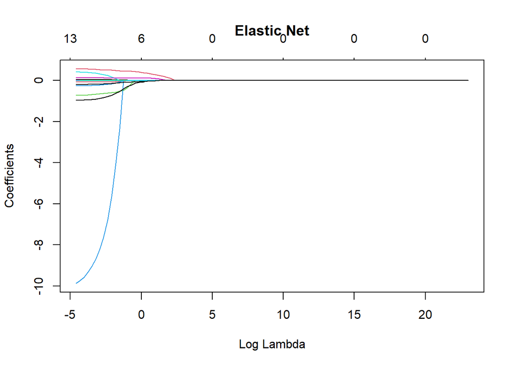

```r
elastic.model <- glmnet(x,
                      y,
                      alpha = 0.5,      #specifies elastic net
                      lambda = grid)
plot(elastic.model,
     xvar = "lambda",
     main = "Elastic Net")
```

We will revisit the models created in part a for evaluation using the validation set approach. Note that the above code chunk did not take a significant amount of run time without the use of multi-core computing. Running the sample parallelization code from class caused my R session to abort.

#### Principle Components Regression

```r
set.seed(1237)
pcr.model <- pcr(crim ~ .,
                 data = boston,
                 scale = TRUE,       #standardizes predictors
                 validataion = "CV"  #10-fold cross validation
                 )
summary(pcr.model)
```

```
## Data:    X dimension: 506 13
##  Y dimension: 506 1
## Fit method: svdpc
## Number of components considered: 13
## TRAINING: % variance explained
##       1 comps  2 comps  3 comps  4 comps  5 comps  6 comps  7 comps  8 comps
## X       47.70    60.36    69.67    76.45    82.99    88.00    91.14    93.45
## crim    30.69    30.87    39.27    39.61    39.61    39.86    40.14    42.47
##       9 comps  10 comps  11 comps  12 comps  13 comps
## X       95.40     97.04     98.46     99.52     100.0
## crim    42.55     42.78     43.04     44.13      45.4
```

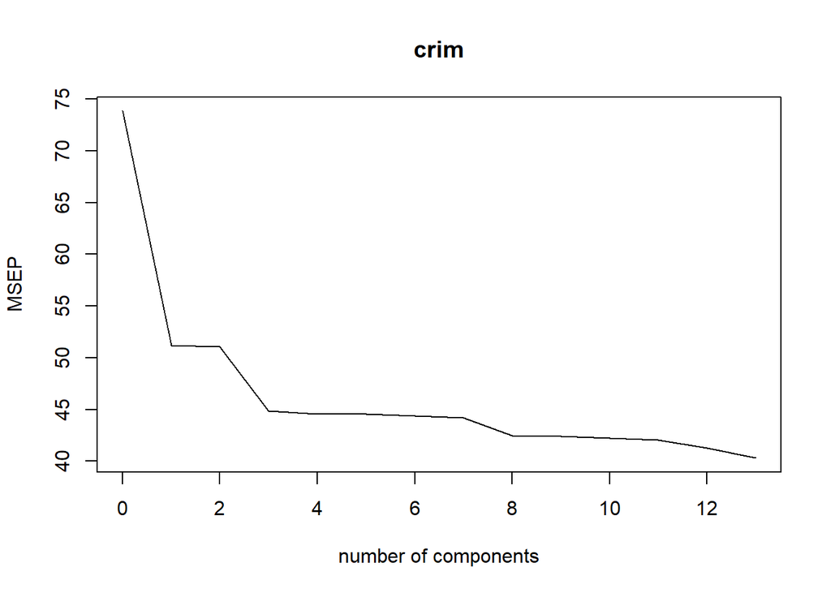

```r
validationplot(pcr.model,
               val.type = "MSEP")
```

To get some idea of how these components are calculated we can look at the output of the prcomp function:

```r
pr.components <- prcomp(boston[c(2,3,4,5,6,7,8,9,10,11,12,13,14)])
pr.components$rotation
```

```
##                   PC1           PC2           PC3           PC4           PC5
## zn      -4.362982e-02  1.109907e-03  0.6323324091  0.7629950202 -0.0995284092
## indus    2.834228e-02 -4.936254e-03 -0.0884404410 -0.0128090985 -0.0742261353
## chas    -5.582384e-05 -1.031037e-04 -0.0009361633  0.0009547877  0.0056275071
## nox      4.498414e-04  1.951391e-06 -0.0018015721  0.0006890438 -0.0002158386
## rm      -1.170985e-03  3.609407e-04  0.0050225895  0.0064210624  0.0512715150
## age      8.365983e-02 -5.683656e-03 -0.7524663867  0.6412615348  0.0703345660
## dis     -6.561191e-03  3.549141e-04  0.0447009047  0.0017394604 -0.0394067712
## rad      4.500013e-02 -8.633441e-03  0.0033738671 -0.0191796967  0.0742947607
## tax      9.498340e-01 -2.924443e-01  0.0949026915 -0.0185334283  0.0174957157
## ptratio  5.605102e-03 -2.521206e-03 -0.0116054999 -0.0330043397 -0.0653526469
## black   -2.912548e-01 -9.561514e-01 -0.0245967658  0.0027986153 -0.0168254127
## lstat    2.296410e-02  5.802358e-03 -0.0947377450  0.0392965020 -0.4698369511
## medv    -2.553188e-02 -8.842219e-03  0.0732666200  0.0553158695  0.8627268473
##                  PC6          PC7          PC8          PC9          PC10
## zn      -0.038382104 -0.004851665 -0.058153662  0.017642786  0.0314066720
## indus   -0.829985382 -0.150465268 -0.514316837  0.007110488 -0.0965309743
## chas    -0.005282465 -0.006999782 -0.005814135 -0.009738987 -0.0062936097
## nox     -0.004258274 -0.002480362 -0.003427089 -0.015486941  0.0145857055
## rm       0.012541770  0.010779789 -0.005832004 -0.004731873 -0.0011917556
## age      0.060270694  0.078714002 -0.007804604  0.009735893 -0.0241626564
## dis      0.083879866  0.076605901  0.026015193  0.123972165 -0.9834384173
## rad      0.525551321 -0.395394701 -0.738069554 -0.118301614 -0.0235921509
## tax     -0.009160805  0.023100919  0.044897328  0.001395587 -0.0004831982
## ptratio  0.077791730  0.057522979 -0.141284287  0.973310048  0.1322525845
## black    0.002830491 -0.004325348 -0.003715614 -0.002727017  0.0006218820
## lstat   -0.018518979 -0.796488017  0.354915645  0.072558234 -0.0306586073
## medv    -0.126841351 -0.412928043  0.196408941  0.131207469 -0.0521417167
##                  PC11          PC12          PC13
## zn      -2.715985e-03  1.653894e-04 -4.584127e-05
## indus    1.350218e-02 -8.429635e-03  4.189054e-03
## chas    -1.887811e-02  9.995695e-01  1.502464e-02
## nox     -1.356028e-03  1.488015e-02 -9.996420e-01
## rm       9.983103e-01  1.863495e-02 -1.097312e-03
## age     -5.465598e-03 -1.058606e-03  8.835471e-04
## dis     -4.917136e-04 -3.344684e-03 -1.702942e-02
## rad     -1.076786e-02 -6.224368e-03  2.668066e-03
## tax      8.927817e-05  4.170502e-04  4.446626e-05
## ptratio  5.762421e-03  1.100037e-02 -1.296832e-02
## black    9.527960e-04 -8.713385e-05 -2.289540e-05
## lstat    3.559016e-02  1.028140e-04 -4.701673e-04
## medv    -3.717210e-02 -6.981370e-03 -2.247175e-03
```

We can see that the first two components are mainly composed of the tax and race variables; whereas the third and fourth are mainly composed of zoning and age variables.

### b

Propose a model (or set of models) that seem to perform well on this data set, and justify your answer. Make sure that you are evaluating model performance using validation set error, cross-validation, or some other reasonable alternative, as opposed to using training error.

We will evaluate the models from part a using the validation set approach. We can specify the testing and training sets with the sample() function, using the seed 1237, for reproducibility:

```r
set.seed(1237)
train <- sample(c(TRUE, FALSE),
                size = nrow(boston),
                replace = TRUE,
                prob = c(0.5, 0.5))
test <- (!train)
sum(test)
```

```
## [1] 252
```

```r
sum(train)
```

```
## [1] 254
```

```r
boston.train <- boston[train,]
boston.test <- boston[test,]
```

#### Best Subset Selections

We can now employ the subset selection procedures on the training data:

```r
#Exhaustive Search
boston.train.ex <- regsubsets(crim ~ .,
                            data = boston.train,
                            method = "exhaustive",
                            nvmax = 13  #specifies max model size
                            )
boston.train.ex.sum <- summary(boston.train.ex)
boston.train.ex.sum
```

```
## Subset selection object
## Call: regsubsets.formula(crim ~ ., data = boston.train, method = "exhaustive",
##     nvmax = 13)
## 13 Variables  (and intercept)
##         Forced in Forced out
## zn          FALSE      FALSE
## indus       FALSE      FALSE
## chas        FALSE      FALSE
## nox         FALSE      FALSE
## rm          FALSE      FALSE
## age         FALSE      FALSE
## dis         FALSE      FALSE
## rad         FALSE      FALSE
## tax         FALSE      FALSE
## ptratio     FALSE      FALSE
## black       FALSE      FALSE
## lstat       FALSE      FALSE
## medv        FALSE      FALSE
## 1 subsets of each size up to 13
## Selection Algorithm: exhaustive
##           zn  indus chas nox rm  age dis rad tax ptratio black lstat medv
## 1  ( 1 )  " " " "   " "  " " " " " " " " "*" " " " "     " "   " "   " "
## 2  ( 1 )  " " " "   " "  " " " " " " " " "*" " " " "     " "   "*"   " "
## 3  ( 1 )  "*" " "   " "  " " " " " " " " "*" " " " "     " "   "*"   " "
## 4  ( 1 )  "*" " "   "*"  " " " " " " " " "*" " " " "     " "   "*"   " "
## 5  ( 1 )  "*" " "   " "  " " " " "*" "*" "*" " " " "     " "   "*"   " "
## 6  ( 1 )  "*" "*"   " "  " " " " " " "*" "*" " " " "     " "   "*"   "*"
## 7  ( 1 )  "*" "*"   " "  " " " " "*" "*" "*" " " " "     " "   "*"   "*"
## 8  ( 1 )  "*" "*"   " "  " " " " "*" "*" "*" " " "*"     " "   "*"   "*"
## 9  ( 1 )  "*" "*"   "*"  " " " " "*" "*" "*" " " "*"     " "   "*"   "*"
## 10  ( 1 ) "*" "*"   "*"  " " " " "*" "*" "*" "*" "*"     " "   "*"   "*"
## 11  ( 1 ) "*" "*"   "*"  "*" " " "*" "*" "*" "*" "*"     " "   "*"   "*"
## 12  ( 1 ) "*" "*"   "*"  "*" " " "*" "*" "*" "*" "*"     "*"   "*"   "*"
## 13  ( 1 ) "*" "*"   "*"  "*" "*" "*" "*" "*" "*" "*"     "*"   "*"   "*"
```

```r
tidy(boston.train.ex)
```

```
## # A tibble: 13 x 18
##    `(Intercept)` zn    indus chas  nox   rm    age   dis   rad   tax   ptratio
##    <lgl>         <lgl> <lgl> <lgl> <lgl> <lgl> <lgl> <lgl> <lgl> <lgl> <lgl>
##  1 TRUE          FALSE FALSE FALSE FALSE FALSE FALSE FALSE TRUE  FALSE FALSE
##  2 TRUE          FALSE FALSE FALSE FALSE FALSE FALSE FALSE TRUE  FALSE FALSE
##  3 TRUE          TRUE  FALSE FALSE FALSE FALSE FALSE FALSE TRUE  FALSE FALSE
##  4 TRUE          TRUE  FALSE TRUE  FALSE FALSE FALSE FALSE TRUE  FALSE FALSE
##  5 TRUE          TRUE  FALSE FALSE FALSE FALSE TRUE  TRUE  TRUE  FALSE FALSE
##  6 TRUE          TRUE  TRUE  FALSE FALSE FALSE FALSE TRUE  TRUE  FALSE FALSE
##  7 TRUE          TRUE  TRUE  FALSE FALSE FALSE TRUE  TRUE  TRUE  FALSE FALSE
##  8 TRUE          TRUE  TRUE  FALSE FALSE FALSE TRUE  TRUE  TRUE  FALSE TRUE
##  9 TRUE          TRUE  TRUE  TRUE  FALSE FALSE TRUE  TRUE  TRUE  FALSE TRUE
## 10 TRUE          TRUE  TRUE  TRUE  FALSE FALSE TRUE  TRUE  TRUE  TRUE  TRUE
## 11 TRUE          TRUE  TRUE  TRUE  TRUE  FALSE TRUE  TRUE  TRUE  TRUE  TRUE
## 12 TRUE          TRUE  TRUE  TRUE  TRUE  FALSE TRUE  TRUE  TRUE  TRUE  TRUE
## 13 TRUE          TRUE  TRUE  TRUE  TRUE  TRUE  TRUE  TRUE  TRUE  TRUE  TRUE
## # ... with 7 more variables: black <lgl>, lstat <lgl>, medv <lgl>,
## #   r.squared <dbl>, adj.r.squared <dbl>, BIC <dbl>, mallows_cp <dbl>
```

```r
#Forward
boston.train.fwd <- regsubsets(crim ~ .,
                            data = boston.train,
                            method = "forward",
                            nvmax = 13  #specifies max model size
                            )
boston.train.fwd.sum <- summary(boston.train.fwd)
boston.train.fwd.sum
```

```
## Subset selection object
## Call: regsubsets.formula(crim ~ ., data = boston.train, method = "forward",
##     nvmax = 13)
## 13 Variables  (and intercept)
##         Forced in Forced out
## zn          FALSE      FALSE
## indus       FALSE      FALSE
## chas        FALSE      FALSE
## nox         FALSE      FALSE
## rm          FALSE      FALSE
## age         FALSE      FALSE
## dis         FALSE      FALSE
## rad         FALSE      FALSE
## tax         FALSE      FALSE
## ptratio     FALSE      FALSE
## black       FALSE      FALSE
## lstat       FALSE      FALSE
## medv        FALSE      FALSE
## 1 subsets of each size up to 13
## Selection Algorithm: forward
##           zn  indus chas nox rm  age dis rad tax ptratio black lstat medv
## 1  ( 1 )  " " " "   " "  " " " " " " " " "*" " " " "     " "   " "   " "
## 2  ( 1 )  " " " "   " "  " " " " " " " " "*" " " " "     " "   "*"   " "
## 3  ( 1 )  "*" " "   " "  " " " " " " " " "*" " " " "     " "   "*"   " "
## 4  ( 1 )  "*" " "   "*"  " " " " " " " " "*" " " " "     " "   "*"   " "
## 5  ( 1 )  "*" " "   "*"  " " " " " " "*" "*" " " " "     " "   "*"   " "
## 6  ( 1 )  "*" " "   "*"  " " " " "*" "*" "*" " " " "     " "   "*"   " "
## 7  ( 1 )  "*" "*"   "*"  " " " " "*" "*" "*" " " " "     " "   "*"   " "
## 8  ( 1 )  "*" "*"   "*"  " " " " "*" "*" "*" " " " "     " "   "*"   "*"
## 9  ( 1 )  "*" "*"   "*"  " " " " "*" "*" "*" " " "*"     " "   "*"   "*"
## 10  ( 1 ) "*" "*"   "*"  " " " " "*" "*" "*" "*" "*"     " "   "*"   "*"
## 11  ( 1 ) "*" "*"   "*"  "*" " " "*" "*" "*" "*" "*"     " "   "*"   "*"
## 12  ( 1 ) "*" "*"   "*"  "*" " " "*" "*" "*" "*" "*"     "*"   "*"   "*"
## 13  ( 1 ) "*" "*"   "*"  "*" "*" "*" "*" "*" "*" "*"     "*"   "*"   "*"
```

```r
tidy(boston.train.fwd)
```

```
## # A tibble: 13 x 18
##    `(Intercept)` zn    indus chas  nox   rm    age   dis   rad   tax   ptratio
##    <lgl>         <lgl> <lgl> <lgl> <lgl> <lgl> <lgl> <lgl> <lgl> <lgl> <lgl>
##  1 TRUE          FALSE FALSE FALSE FALSE FALSE FALSE FALSE TRUE  FALSE FALSE
##  2 TRUE          FALSE FALSE FALSE FALSE FALSE FALSE FALSE TRUE  FALSE FALSE
##  3 TRUE          TRUE  FALSE FALSE FALSE FALSE FALSE FALSE TRUE  FALSE FALSE
##  4 TRUE          TRUE  FALSE TRUE  FALSE FALSE FALSE FALSE TRUE  FALSE FALSE
##  5 TRUE          TRUE  FALSE TRUE  FALSE FALSE FALSE TRUE  TRUE  FALSE FALSE
##  6 TRUE          TRUE  FALSE TRUE  FALSE FALSE TRUE  TRUE  TRUE  FALSE FALSE
##  7 TRUE          TRUE  TRUE  TRUE  FALSE FALSE TRUE  TRUE  TRUE  FALSE FALSE
##  8 TRUE          TRUE  TRUE  TRUE  FALSE FALSE TRUE  TRUE  TRUE  FALSE FALSE
##  9 TRUE          TRUE  TRUE  TRUE  FALSE FALSE TRUE  TRUE  TRUE  FALSE TRUE
## 10 TRUE          TRUE  TRUE  TRUE  FALSE FALSE TRUE  TRUE  TRUE  TRUE  TRUE
## 11 TRUE          TRUE  TRUE  TRUE  TRUE  FALSE TRUE  TRUE  TRUE  TRUE  TRUE
## 12 TRUE          TRUE  TRUE  TRUE  TRUE  FALSE TRUE  TRUE  TRUE  TRUE  TRUE
## 13 TRUE          TRUE  TRUE  TRUE  TRUE  TRUE  TRUE  TRUE  TRUE  TRUE  TRUE
## # ... with 7 more variables: black <lgl>, lstat <lgl>, medv <lgl>,
## #   r.squared <dbl>, adj.r.squared <dbl>, BIC <dbl>, mallows_cp <dbl>
```

```r
#Backward
boston.train.bwd <- regsubsets(crim ~ .,
                            data = boston.train,
                            method = "backward",
                            nvmax = 13  #specifies max model size
                            )
boston.train.bwd.sum <- summary(boston.train.bwd)
boston.train.bwd.sum
```

```
## Subset selection object
## Call: regsubsets.formula(crim ~ ., data = boston.train, method = "backward",
##     nvmax = 13)
## 13 Variables  (and intercept)
##         Forced in Forced out
## zn          FALSE      FALSE
## indus       FALSE      FALSE
## chas        FALSE      FALSE
## nox         FALSE      FALSE
## rm          FALSE      FALSE
## age         FALSE      FALSE
## dis         FALSE      FALSE
## rad         FALSE      FALSE
## tax         FALSE      FALSE
## ptratio     FALSE      FALSE
## black       FALSE      FALSE
## lstat       FALSE      FALSE
## medv        FALSE      FALSE
## 1 subsets of each size up to 13
## Selection Algorithm: backward
##           zn  indus chas nox rm  age dis rad tax ptratio black lstat medv
## 1  ( 1 )  " " " "   " "  " " " " " " " " "*" " " " "     " "   " "   " "
## 2  ( 1 )  " " " "   " "  " " " " " " " " "*" " " " "     " "   "*"   " "
## 3  ( 1 )  "*" " "   " "  " " " " " " " " "*" " " " "     " "   "*"   " "
## 4  ( 1 )  "*" " "   " "  " " " " " " "*" "*" " " " "     " "   "*"   " "
## 5  ( 1 )  "*" " "   " "  " " " " " " "*" "*" " " " "     " "   "*"   "*"
## 6  ( 1 )  "*" "*"   " "  " " " " " " "*" "*" " " " "     " "   "*"   "*"
## 7  ( 1 )  "*" "*"   " "  " " " " "*" "*" "*" " " " "     " "   "*"   "*"
## 8  ( 1 )  "*" "*"   " "  " " " " "*" "*" "*" " " "*"     " "   "*"   "*"
## 9  ( 1 )  "*" "*"   "*"  " " " " "*" "*" "*" " " "*"     " "   "*"   "*"
## 10  ( 1 ) "*" "*"   "*"  " " " " "*" "*" "*" "*" "*"     " "   "*"   "*"
## 11  ( 1 ) "*" "*"   "*"  "*" " " "*" "*" "*" "*" "*"     " "   "*"   "*"
## 12  ( 1 ) "*" "*"   "*"  "*" " " "*" "*" "*" "*" "*"     "*"   "*"   "*"
## 13  ( 1 ) "*" "*"   "*"  "*" "*" "*" "*" "*" "*" "*"     "*"   "*"   "*"
```

```r
tidy(boston.train.bwd)
```

```
## # A tibble: 13 x 18
##    `(Intercept)` zn    indus chas  nox   rm    age   dis   rad   tax   ptratio
##    <lgl>         <lgl> <lgl> <lgl> <lgl> <lgl> <lgl> <lgl> <lgl> <lgl> <lgl>
##  1 TRUE          FALSE FALSE FALSE FALSE FALSE FALSE FALSE TRUE  FALSE FALSE
##  2 TRUE          FALSE FALSE FALSE FALSE FALSE FALSE FALSE TRUE  FALSE FALSE
##  3 TRUE          TRUE  FALSE FALSE FALSE FALSE FALSE FALSE TRUE  FALSE FALSE
##  4 TRUE          TRUE  FALSE FALSE FALSE FALSE FALSE TRUE  TRUE  FALSE FALSE
##  5 TRUE          TRUE  FALSE FALSE FALSE FALSE FALSE TRUE  TRUE  FALSE FALSE
##  6 TRUE          TRUE  TRUE  FALSE FALSE FALSE FALSE TRUE  TRUE  FALSE FALSE
##  7 TRUE          TRUE  TRUE  FALSE FALSE FALSE TRUE  TRUE  TRUE  FALSE FALSE
##  8 TRUE          TRUE  TRUE  FALSE FALSE FALSE TRUE  TRUE  TRUE  FALSE TRUE
##  9 TRUE          TRUE  TRUE  TRUE  FALSE FALSE TRUE  TRUE  TRUE  FALSE TRUE
## 10 TRUE          TRUE  TRUE  TRUE  FALSE FALSE TRUE  TRUE  TRUE  TRUE  TRUE
## 11 TRUE          TRUE  TRUE  TRUE  TRUE  FALSE TRUE  TRUE  TRUE  TRUE  TRUE
## 12 TRUE          TRUE  TRUE  TRUE  TRUE  FALSE TRUE  TRUE  TRUE  TRUE  TRUE
## 13 TRUE          TRUE  TRUE  TRUE  TRUE  TRUE  TRUE  TRUE  TRUE  TRUE  TRUE
## # ... with 7 more variables: black <lgl>, lstat <lgl>, medv <lgl>,
## #   r.squared <dbl>, adj.r.squared <dbl>, BIC <dbl>, mallows_cp <dbl>
```

Create the model matrix for the testing dataset:

```r
test.matrix <- model.matrix(crim ~ ., data = boston.test)
```

Computing test MSE for each exhaustive search model:

```r
val.errors <- rep(NA, 13)     #13 = dim(names(boston))-1
for (i in 1:13) {             #13 = dim(names(boston))-1
  coefi <- coef(boston.train.ex, id = i)
  pred <- test.matrix[, names(coefi)] %*% coefi
  val.errors[i] <- mean((boston.test$crim - pred)^2)
}
val.errors
```

```
##  [1] 57.94524 56.26378 56.23731 56.13667 56.17211 54.53553 54.89544 54.79707
##  [9] 54.73233 54.64253 54.30290 53.94749 54.00789
```

```r
which.min(val.errors)
```

```
## [1] 12
```

We find that the 12-parameter exhaustive model has minimum MSE of 53.94749.

Computing test MSE for each forward search model:

```r
val.errors <- rep(NA, 13)     #13 = dim(names(boston))-1
for (i in 1:13) {             #13 = dim(names(boston))-1
  coefi <- coef(boston.train.fwd, id = i)
  pred <- test.matrix[, names(coefi)] %*% coefi
  val.errors[i] <- mean((boston.test$crim - pred)^2)
}
val.errors
```

```
##  [1] 57.94524 56.26378 56.23731 56.13667 55.64086 55.94611 55.81854 54.84148
##  [9] 54.73233 54.64253 54.30290 53.94749 54.00789
```

```r
which.min(val.errors)
```

```
## [1] 12
```

We find that the 12-parameter forward search model has minimum MSE of 53.94749.

Computing test MSE for each backward search model:

```r
val.errors <- rep(NA, 13)     #13 = dim(names(boston))-1
for (i in 1:13) {             #13 = dim(names(boston))-1
  coefi <- coef(boston.train.bwd, id = i)
  pred <- test.matrix[, names(coefi)] %*% coefi
  val.errors[i] <- mean((boston.test$crim - pred)^2)
}
val.errors
```

```
##  [1] 57.94524 56.26378 56.23731 55.82241 54.95856 54.53553 54.89544 54.79707
##  [9] 54.73233 54.64253 54.30290 53.94749 54.00789
```

```r
which.min(val.errors)
```

```
## [1] 12
```

We find that the 12-parameter backward search model has minimum MSE of 53.94749. Here are the parameters of the 12-parameter model on the full dataset:

```r
coef(regfit.ex, 12)
```

```
##   (Intercept)            zn         indus          chas           nox
##  16.985713928   0.044673247  -0.063848469  -0.744367726 -10.202169211
##            rm           dis           rad           tax       ptratio
##   0.439588002  -0.993556631   0.587660185  -0.003767546  -0.269948860
##         black         lstat          medv
##  -0.007518904   0.128120290  -0.198877768
```

#### Shrinkage Methods

We can now apply the testing and training set approach to the shrinkage methods. This code specifies model matrices as x values, and crime rate vector as y values for the shrinkage methods:

```r
x.train <- model.matrix(crim ~ .,
                  data = boston.train)
y.train <- boston.train$crim
x.test <- model.matrix(crim ~ .,
                  data = boston.test)
y.test <- boston.test$crim
```

As in the example in the text, we will choose a range of $\lambda$ values from $10^{-2}$ to $10^{10}$, and fit models for this range of parameters:

```r
grid <- 10^seq(10, -2, length = 100)  #specifies 100 lambda values
```

The following code creates the lasso model and plots the coefficients as a function of log-$\lambda$:

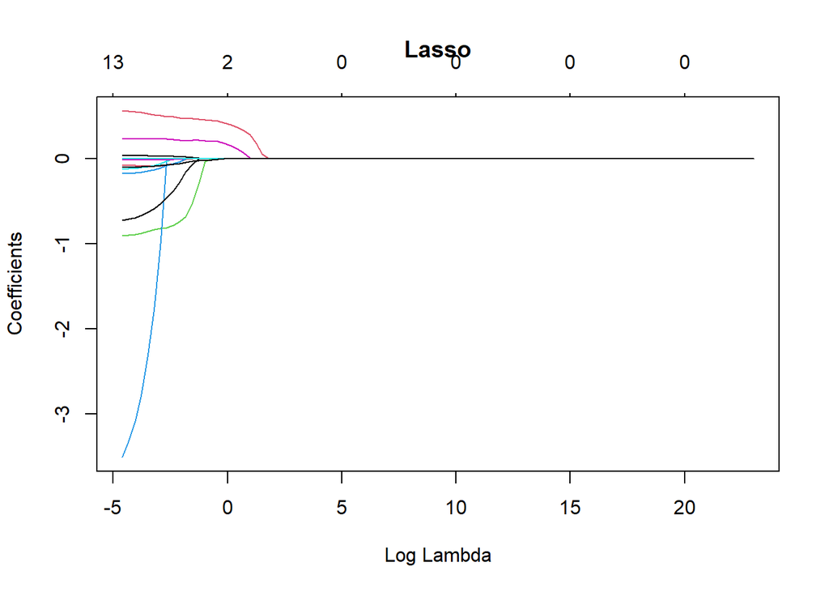

```r
lasso.train <- glmnet(x.train,
                      y.train,
                      alpha = 1,      #specifies lasso
                      lambda = grid)
plot(lasso.train,
     xvar = "lambda",
     main = "Lasso")
```

For an arbitrarily chosen $\lambda$ value (we will use 4, as in the text) we can compute the testing MSE:

```r
lasso.pred <- predict(lasso.train,
                      s = 4,
                      newx = x.test)
mean((lasso.pred - y.test)^2)
```

```
## [1] 78.37274
```

We obtain an MSE of 78.37274; not great compared to the subset selection methods.

The following code creates the ridge model and plots the coefficients as a function of log-$\lambda$:

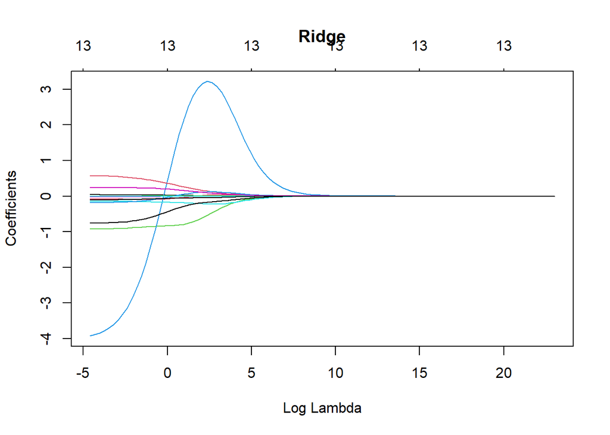

```r
ridge.train <- glmnet(x.train,
                      y.train,
                      alpha = 0,      #specifies ridge
                      lambda = grid)
plot(ridge.train,
     xvar = "lambda",
     main = "Ridge")
```

For an arbitrarily chosen $\lambda$ value (we will use 4, as in the text) we can compute the testing MSE:

```r
ridge.pred <- predict(ridge.train,
                      s = 4,
                      newx = x.test)
mean((ridge.pred - y.test)^2)
```

```
## [1] 56.77245
```

We obtain an MSE of 56.77245; not bad.

The following code creates the elastic net model and plots the coefficients as a function of log-$\lambda$:

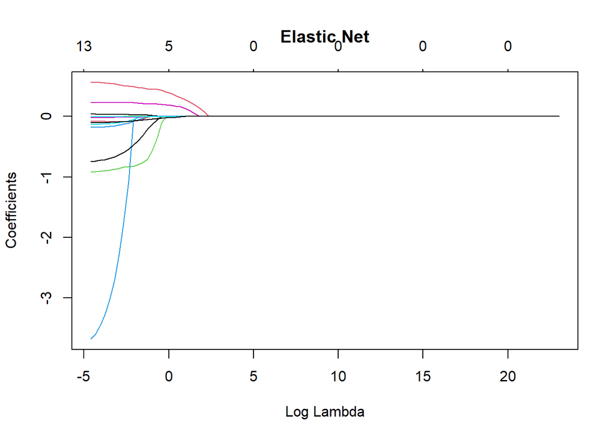

```r
net.train <- glmnet(x.train,
                      y.train,
                      alpha = 0.5,      #specifies elastic net
                      lambda = grid)
plot(net.train,
     xvar = "lambda",
     main = "Elastic Net")
```

For an arbitrarily chosen $\lambda$ value (we will use 4, as in the text) we can compute the testing MSE:

```r
net.pred <- predict(net.train,
                      s = 4,
                      newx = x.test)
mean((net.pred - y.test)^2)
```

```
## [1] 65.26999
```

We obtain an MSE of 65.26999; not great compared to the subset selection methods.

Coefficients of the full dataset ridge regression model with lambda = 4:

```r
coef(ridge.model, s = 4)
```

```
## 15 x 1 sparse Matrix of class "dgCMatrix"
##                       s1
## (Intercept)  0.487667487
## (Intercept)  .
## zn           0.016504064
## indus       -0.010919880
## chas        -0.755199754
## nox          1.142808085
## rm           0.072776479
## age          0.006346738
## dis         -0.298997498
## rad          0.234272114
## tax          0.006676408
## ptratio      0.059551921
## black       -0.008735843
## lstat        0.114172940
## medv        -0.074123573
```

#### Conclusion

The Subset selection models have the least testing MSE, and thus have the best performance, however the ridge regression model is close. The conventional subset selection models, arguably should be chosen.

### c

Does your chosen model involve all of the features in the data set? Why or why not?

# References

1. Breiman L. Statistical Modeling: The Two Cultures. Statistical Science. Published online 2001:33.
2. James G, Witten D, Hastie T, Tibshirani R. An Introduction to Statistical Learning: With Applications in R. 1st ed. 2013, Corr. 7th printing 2017 edition. Springer; 2013.